# Week_6_Practical

Owen Hughes

2025-11-11

# This week the goal is to explore analysis of point clusters in a number of different ways

**As always the first steps are to load libraries and data**

```r
# Libraries
# install.packages("spatstat")
library(spatstat)
library(here)
library(sp)
library(tmap)
library(sf)
library(tmaptools)
library(tidyverse)
```

```r
library(ggplot2)
```

```r
# Read in the data
LondonBoroughs <- st_read(here::here("Week_6_prac_and_hw/statistical-gis-boundaries-london/statistical-gis-boundaries-london/ESRI/London_Borough_Excluding_MHW.shp"))
```

Let’s now inspect the LondonBorough data.

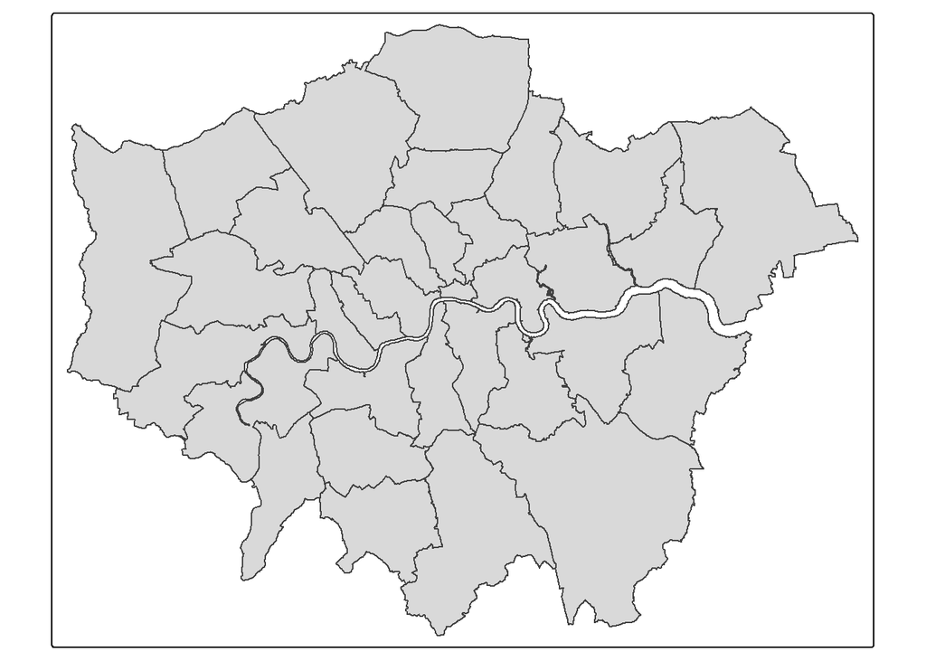

```r
# Quick Map
library(stringr)
BoroughMap <- LondonBoroughs %>%
  dplyr::filter(str_detect(GSS_CODE, "^E09"))%>%
  st_transform(., 27700)

qtm(BoroughMap)
```

```r
# Summary Stats
summary(BoroughMap)
```

```
##      NAME             GSS_CODE            HECTARES         NONLD_AREA
##  Length:33          Length:33          Min.   :  314.9   Min.   :  0.00
##  Class :character   Class :character   1st Qu.: 2724.9   1st Qu.:  0.00
##  Mode  :character   Mode  :character   Median : 3857.8   Median :  2.30
##                                        Mean   : 4832.4   Mean   : 64.22
##                                        3rd Qu.: 5658.5   3rd Qu.: 95.60
##                                        Max.   :15013.5   Max.   :370.62
##   ONS_INNER           SUB_2009           SUB_2006                  geometry
##  Length:33          Length:33          Length:33          MULTIPOLYGON :33
##  Class :character   Class :character   Class :character   epsg:27700   : 0
##  Mode  :character   Mode  :character   Mode  :character   +proj=tmer...: 0
##
##
##
```

Now let’s load the blue plaques data that we will use for the analysis in this practical

```r
BluePlaques <- st_read(here::here("Week_6_prac_and_hw/open_plaques.geojson")) %>%
  st_transform(.,27700)
summary(BluePlaques)
```

```
##        id          inscription                 geometry
##  Min.   :    1.0   Length:2812        POINT        :2812
##  1st Qu.:  711.8   Class :character   epsg:27700   :   0
##  Median : 6089.0   Mode  :character   +proj=tmer...:   0
##  Mean   :10622.0
##  3rd Qu.:10358.2
##  Max.   :49190.0
```

**Now I want to plot the blue plaques on top of the London Boroughs**

```r
tmap_mode("plot")
```

```
## ℹ tmap modes "plot" - "view"
## ℹ toggle with `tmap::ttm()`
```

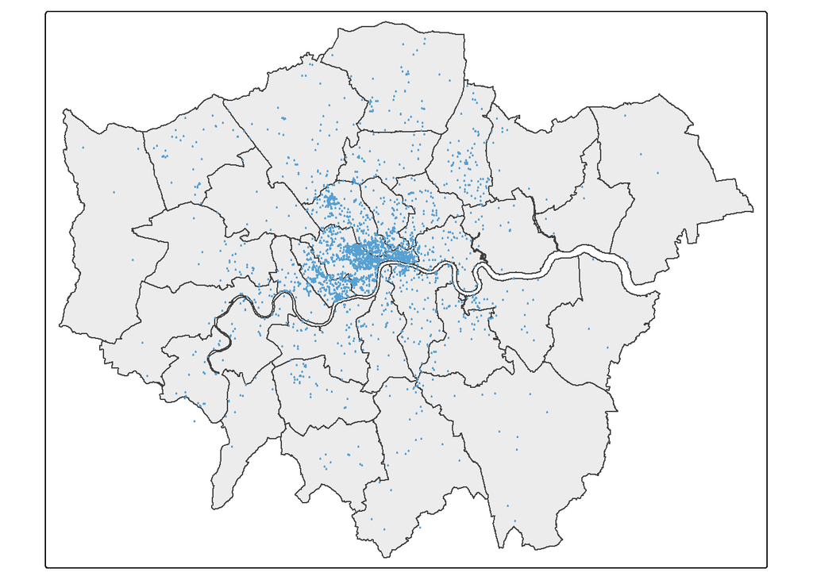

```r
tm_shape(BoroughMap) +
  tm_polygons(fill_alpha = 0.5) +
tm_shape(BluePlaques) +
  tm_dots(fill = "#57a0d2", size = 0.1)
```

I can see there are a lot of blue plaques in the city of London, Westminster, Camden, Islington?, and fewer once one exits the center of London.

**There is a plaque point outside of the city, let’s clip the points to the city boundary to avoid issues with the analysis**

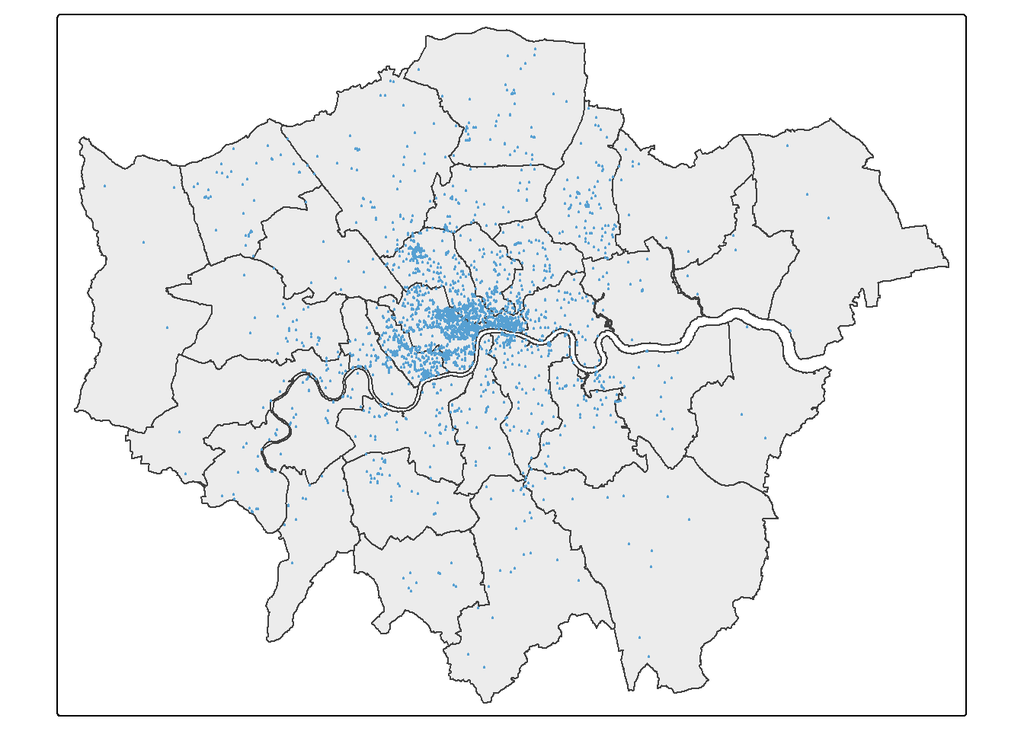

```r
# Remove duplicates
BluePlaques <- distinct(BluePlaques)

# Clip the points
BluePlaquesSub <- BluePlaques[BoroughMap,]
# This code can be used with any topological operator like: intersect or within

tm_shape(BoroughMap) +
  tm_polygons(fill_alpha = 0.5) +
tm_shape(BluePlaquesSub) +
  tm_dots(fill = "#57a0d2", size = 0.1)
```

Great! The errant points have been removed and we’re a go for continued analysis.

**Choose a borough for more the sake of the example** Because of the amount of points in the data set for the whole city, choosing a borough will help speed up the process. I am going to choose Lambeth because I like Brixton a lot.

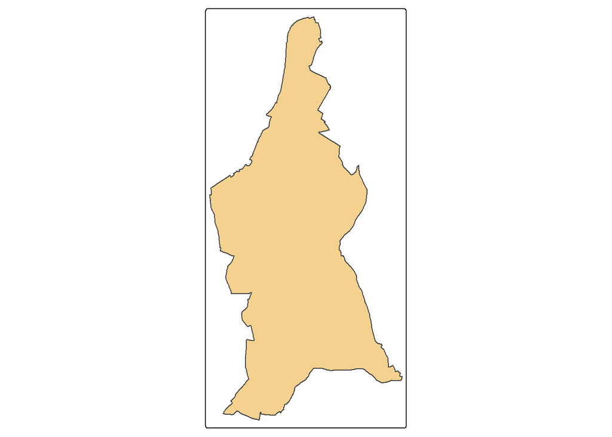

```r
# Extract Lambeth
Lambeth <- BoroughMap %>%
  filter(., NAME=="Lambeth")

# Check to verify it's correct
tm_shape(Lambeth)+
  tm_polygons(fill = "#EAA221", fill_alpha = 0.5)
```

Now I want to clip the plaques in Lambeth to the map above and check

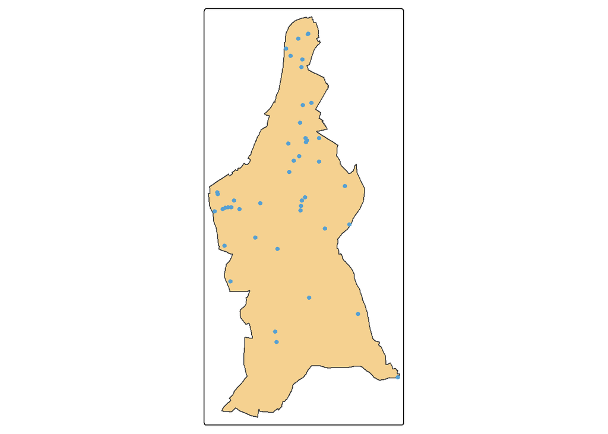

```r
# Clip to Lambeth
BluePlaquesLam <- BluePlaques[Lambeth,]

# Map to check
tm_shape(Lambeth) +
  tm_polygons(fill = "#EAA221", fill_alpha = 0.5)+
tm_shape(BluePlaquesLam) +
  tm_dots(fill = "#57a0d2", size = 0.3) # slightly larger dots are easier to see
```

**Final setup for point cloud analysis**

Create a spatstat observation window

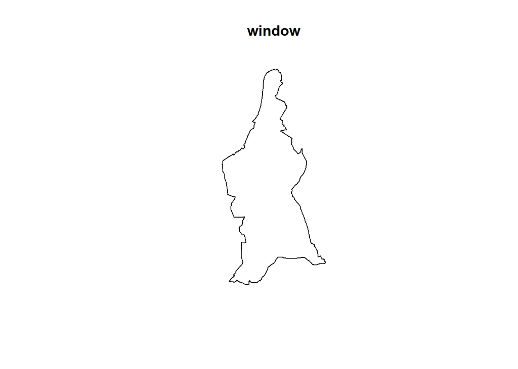

```r
#now set a window as the borough boundary
window <- as.owin(Lambeth)
plot(window)
```

Spatstat does not work directly with sf objects so let’s convert the data to something that spatstat can read properly.

```r
#create a sp object
BluePlaquesLam<- BluePlaquesLam %>%
  as(., 'Spatial')
#create a ppp object
BluePlaquesLam.ppp <- ppp(x=BluePlaquesLam@coords[,1], # grabs lat + long from geometry column
                          y=BluePlaquesLam@coords[,2],
                          window=window)
```

Inspect the new spatstat object

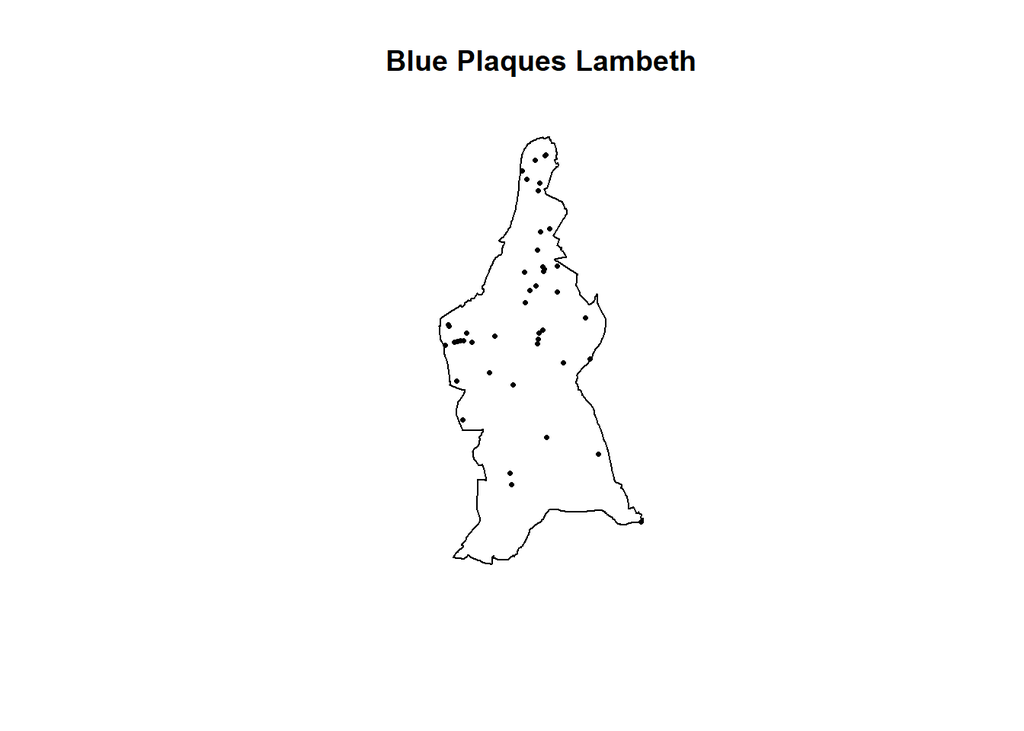

```r
BluePlaquesLam.ppp %>%
  plot(.,pch=16,cex=0.5,
       main="Blue Plaques Lambeth")
```

## Point Pattern Analysis

**Kernel Density Estimation**

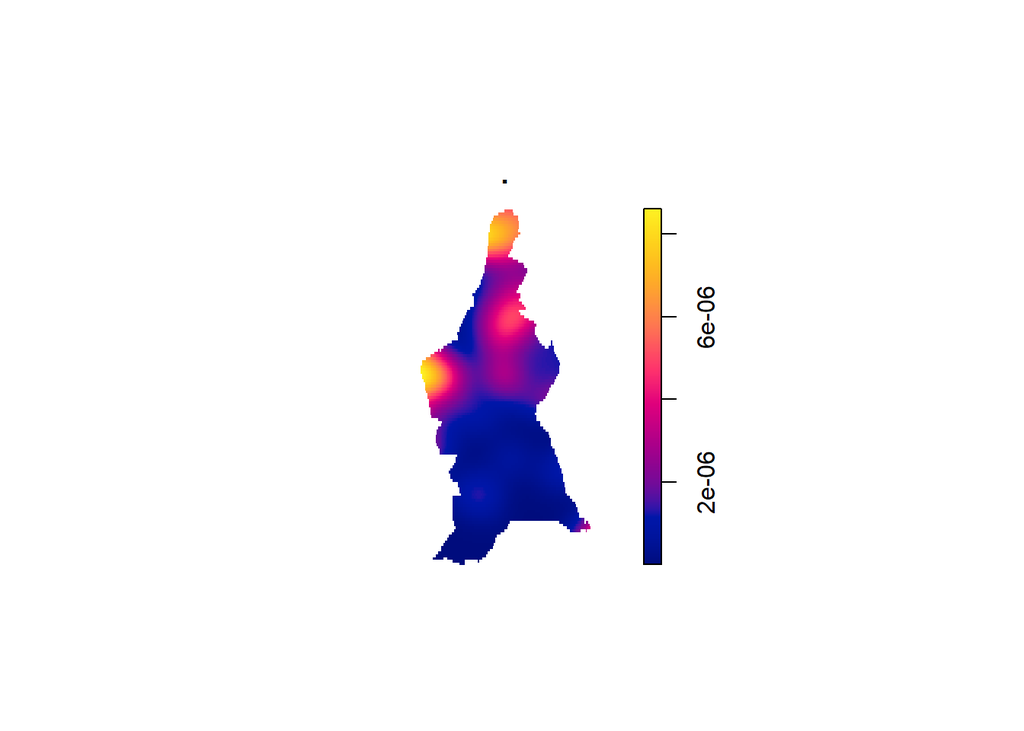

```r
# Plot the density of the points on a color scale
BluePlaquesLam.ppp %>%
  density(., sigma=500) %>%
  plot()
```

What happens with a different sigma data?

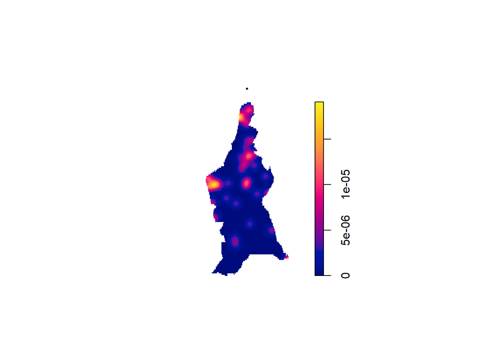

```r
BluePlaquesLam.ppp %>%
  density(., sigma=200) %>%
  plot()
```

**Quadrat Analysis**

I want to make a distribution of the amount of points within a set amount of quadrats (squares) within Lambeth. These are the steps to do so.

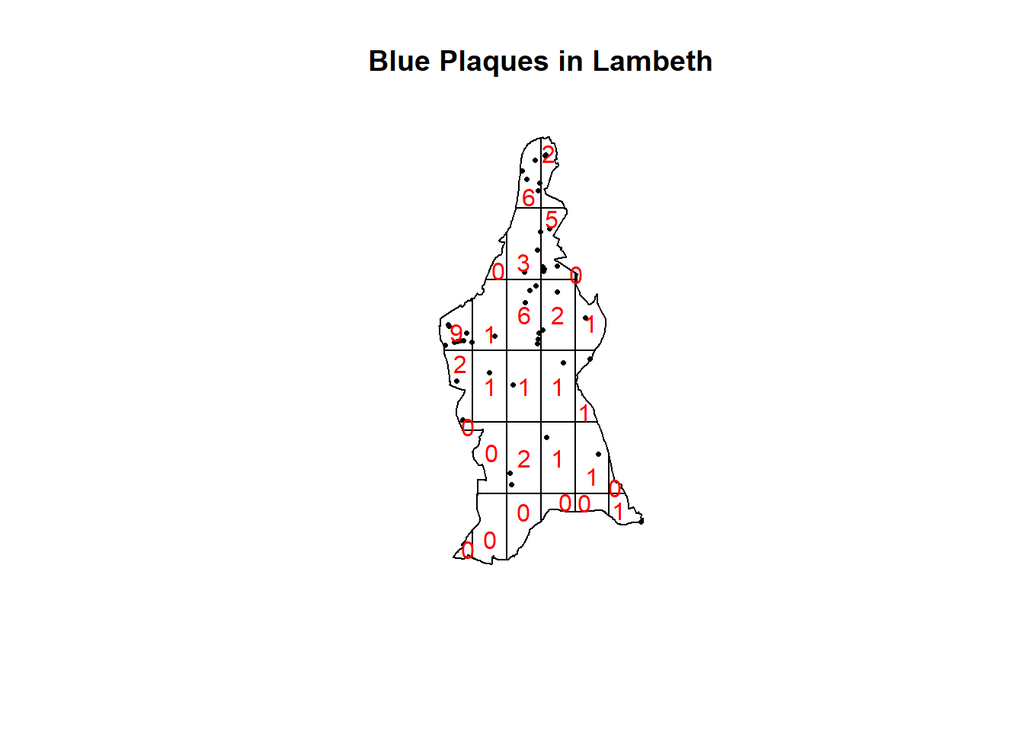

```r
#First plot the points
plot(BluePlaquesLam.ppp,
     pch=16,
     cex=0.5,
     main="Blue Plaques in Lambeth")

#now count the points in that fall in a 6 x 6
#grid overlaid across the window BluePlaquesLam.ppp2<-BluePlaquesLam.ppp %>%
BluePlaquesLam.ppp %>%
  quadratcount(.,nx = 6, ny = 6)%>%
    plot(., add=T, col="red")
```

This displays the same clustering as the kernel.

Now I want to take the data from above and save it into a table.

```r
#run the quadrat count
Qcount <- BluePlaquesLam.ppp %>%
  quadratcount(.,nx = 6, ny = 6) %>%
  as.data.frame() %>%
  dplyr::count(Var1=Freq)%>%
  dplyr::rename(Freqquadratcount=n)

view(Qcount)
```

Let’s now summarize the data.

```r
Qcount %>%
  summarize_all(class)
```

```
##      Var1 Freqquadratcount
## 1 integer          integer
```

Now we need to calculate the expected values for the data. This includes pulling the Lamda into a value

```r
sums <- Qcount %>%
  #calculate the total blue plaques (Var * Freq)
  mutate(total = Var1 * Freqquadratcount) %>%
  dplyr::summarise(across(everything(), sum))%>%
  dplyr::select(-Var1)

lambda<- Qcount%>%
  #calculate lambda
  mutate(total = Var1 * Freqquadratcount)%>%
  dplyr::summarise(across(everything(), sum)) %>%
  mutate(lambda=total/Freqquadratcount) %>%
  dplyr::select(lambda)%>%
  pull(lambda)
```

Now, using the Poisson distribution, one can use the variables and data sets from above to calculate the expected values.

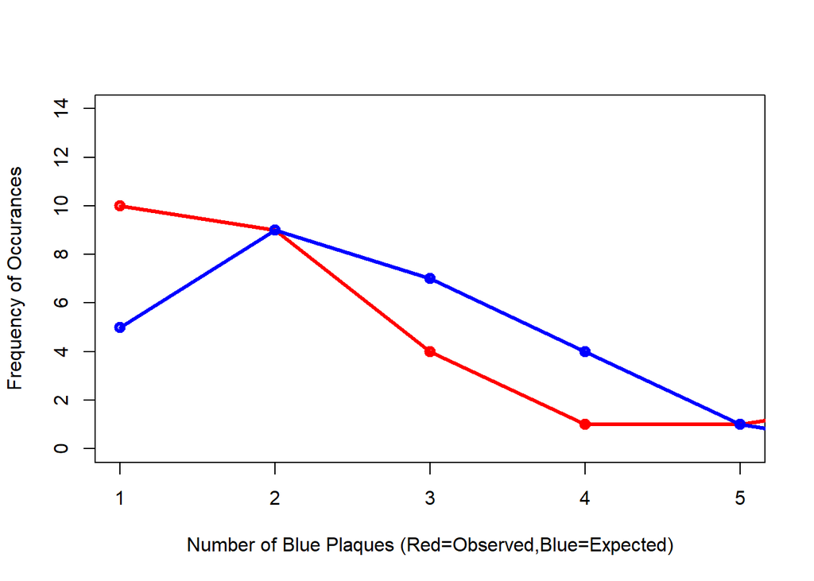

```r
QCountTable <- Qcount %>%
  mutate(Pr=((lambda^Var1)*exp(-lambda))/factorial(Var1))%>%
  #now calculate the expected counts based on our total number of plaques
  #and save them to the table
  mutate(Expected= (round(Pr * sums$Freqquadratcount, 0)))

#Compare the frequency distributions of the observed and expected point patterns
plot(c(1,5),c(0,14), type="n",
xlab="Number of Blue Plaques (Red=Observed,Blue=Expected)",
     ylab="Frequency of Occurances")
points(QCountTable$Freqquadratcount,
       col="Red",
       type="o",
       lwd=3)
points(QCountTable$Expected, col="Blue",
       type="o",
       lwd=3)
```

```r
teststats <- quadrat.test(BluePlaquesLam.ppp, nx = 6, ny = 6)
```

[figure not shown]

```r
plot(BluePlaquesLam.ppp,pch=16,cex=0.5, main="Blue Plaques in Harrow")
plot(teststats, add=T, col = "red")
```

**Ripley’s K**

Ripley’s K computes spatial clustering using a poisson distribution and a series of concentrix radii around each point in question.

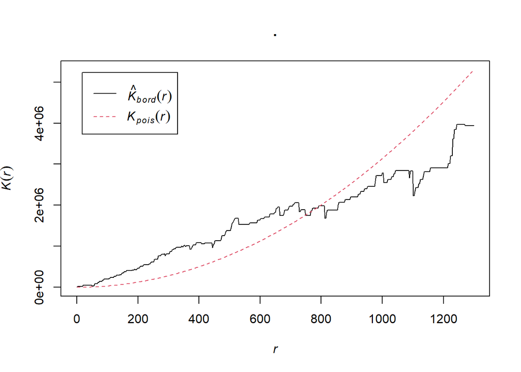

```r
# Graph the point data agains the Poisson distribution
K <- BluePlaquesLam.ppp %>%
  Kest(., correction="border") %>%
  plot()
```

Let’s save this data into a data set.

```r
# we can also extract the plot into a data frame
Kval <- as.data.frame(Kest(BluePlaquesLam.ppp, correction = "Ripley"))
```

One issue with Ripley’s K is that is doesn’t allow for a visualization of its data in a map. This means we don’t really know where the clusters are.

**Density-based spatial clustering of applications with noise: DBSCAN**

DBSCAN is a way for us to better visualize where the clustering in an area is happening.

```r
#install.packages('fpc')
library(fpc)
#first check the coordinate reference system of the Harrow spatial polygon:
st_geometry(BoroughMap)
```

```
## Geometry set for 33 features
## Geometry type: MULTIPOLYGON
## Dimension:     XY
## Bounding box:  xmin: 503568.2 ymin: 155850.8 xmax: 561957.5 ymax: 200933.9
## Projected CRS: OSGB36 / British National Grid
## First 5 geometries:
```

```
## MULTIPOLYGON (((516401.6 160201.8, 516407.3 160...
```

```
## MULTIPOLYGON (((535009.2 159504.7, 535005.5 159...
```

```
## MULTIPOLYGON (((540373.6 157530.4, 540361.2 157...
```

```
## MULTIPOLYGON (((521975.8 178100, 521967.7 17809...
```

```
## MULTIPOLYGON (((510253.5 182881.6, 510249.9 182...
```

```r
st_geometry(Lambeth)
```

```
## Geometry set for 1 feature
## Geometry type: MULTIPOLYGON
## Dimension:     XY
## Bounding box:  xmin: 528519.3 ymin: 169648 xmax: 533716.6 ymax: 180529.5
## Projected CRS: OSGB36 / British National Grid
```

```
## MULTIPOLYGON (((530046.8 177893.4, 530048.4 177...
```

DBSCAN requires you to input two parameters: 1. Epsilon - this is the radius within which the algorithm with search for clusters 2. MinPts - this is the minimum number of points that should be considered a cluster

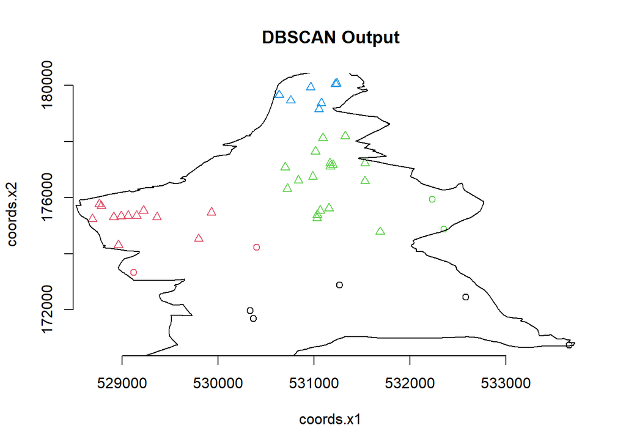

```r
#first extract the points from the spatial points data frame
BluePlaquesLamPoints <- BluePlaquesLam %>%
  coordinates(.)%>%
  as.data.frame()

#now run the dbscan analysis
db <- BluePlaquesLamPoints %>%
  fpc::dbscan(.,eps = 1000, MinPts = 4)

#now plot the results
plot(db, BluePlaquesLamPoints, main = "DBSCAN Output", frame = F)
plot(Lambeth$geometry, add=T)
```

What if I wanted to find a more optimal EPS value?

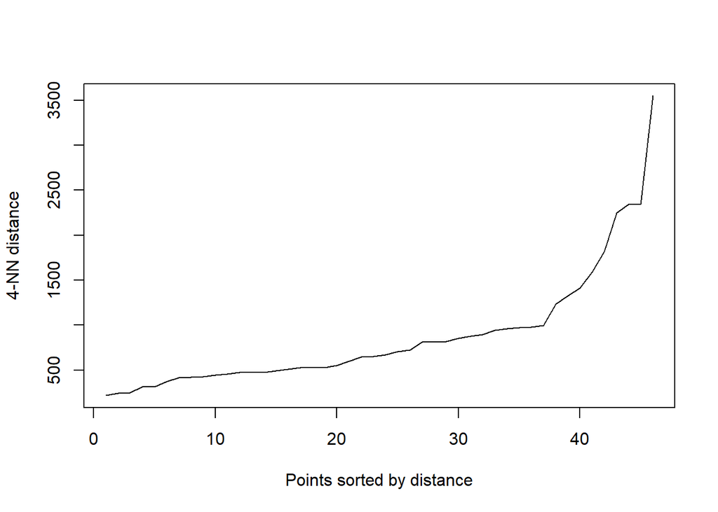

```r
# used to find suitable eps value based on the knee in plot
# k is no of nearest neighbors used, use min points
# install.packages("dbscan")
library(dbscan)
BluePlaquesLamPoints%>%
  dbscan::kNNdistplot(.,k=4)
```

Now let’s make a much nicer plot for display.

```r
db
```

```
## dbscan Pts=46 MinPts=4 eps=1000
##        0  1  2 3
## border 5  2  2 0
## seed   0 12 17 8
## total  5 14 19 8
```

```r
print('-----------------------------------------------------------------------------------------')
```

```
## [1] "-----------------------------------------------------------------------------------------"
```

```r
db$cluster
```

```
##  [1] 1 2 2 1 2 3 1 1 2 2 0 2 1 2 2 2 3 2 1 2 3 1 3 2 3 1 2 0 1 0 0 2 0 3 1 1 3 1
## [39] 2 2 1 3 1 2 2 2
```

```r
# add this cluster membership info back into our data frame
BluePlaquesLamPoints<- BluePlaquesLamPoints %>%
  mutate(dbcluster=db$cluster)
```

Now we are going to create convex hull polygons (minimum bounding polygons) that surround the clusters. Transforming theses polygons into sf objects will allow them to be visualized more aesthetically in a map.

```r
# convert the data frame to sf
BluePlaquesLamPoints_sf <- st_as_sf(BluePlaquesLamPoints,
                                    coords = c("coords.x1", "coords.x2"),
                                    crs = 27700)

# make the convex hulls around the cluster points
chull_polygons <- BluePlaquesLamPoints_sf %>%
  # remove any points not in a cluster
  filter(dbcluster>0)%>%
  group_by(dbcluster) %>%
  summarise(geometry = st_combine(geometry)) %>%  # combine points
  mutate(geometry = st_convex_hull(geometry)) %>% # convex hull
  st_as_sf()
```

Now that we have this Convex Hull data, let’s make a good looking map to go along.

```r
#install.packages("ggspatial")
#install.packages("prettymapr")
library(ggspatial)
library(prettymapr)
```

```
## Zoom: 13
```

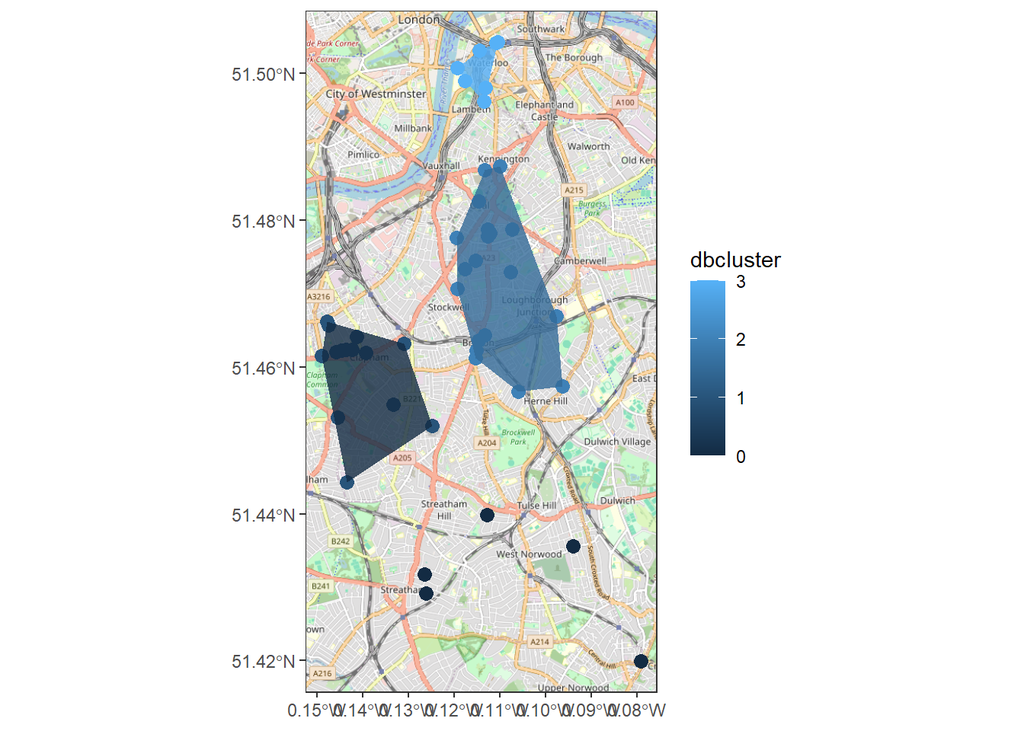

```r
# Create the map
ggplot() +
  annotation_map_tile(zoom = 13) +
  geom_sf(data = BluePlaquesLamPoints_sf, aes(color=dbcluster), size = 3)+
  geom_sf(data = chull_polygons, aes(fill = dbcluster),
          alpha = 0.8,
          # remove polygon borders
          color = NA,
          show.legend = FALSE) +

  theme_bw()
```

Bing Bang Bosh!